# PM566 Final Project

Author

Liying Deng

# Description

For my public health analytics project, I leverage data-driven insights to explore tobacco use patterns in the United States. Tobacco use remains a significant public health concern, with prevalence and usage patterns varying widely across states due to factors like demographics, cultural norms, public health initiatives, and socioeconomic conditions. Using data from Alaska and Alabama, this project highlights how tobacco behaviors differ in two demographically and geographically distinct regions of the U.S.

Through this study, I investigate key questions about tobacco use trends, focusing on both traditional products such as cigarettes and smokeless tobacco, as well as newer alternatives like e-cigarettes. The analysis covers annual usage trends from 2017 to 2019, demographic differences such as age, gender, and education, and comparisons between the two states. While the study does not evaluate specific smoking cessation strategies, it provides critical insights that can guide the design of future public health initiatives and evidence-based smoking cessation campaigns.

Through in-depth analysis and data visualization, we will discover:

1. The differences in Cigarette use patterns between a geographically isolated state (Alaska) and a historically tobacco-favoring southeastern state (Alabama).
2. Trends in the prevalence of specific tobacco products, including e-cigarettes, across different years and demographic groups.
3. Insights into how age, gender, and education levels influence tobacco usage rates, offering opportunities for targeted interventions.
4. A comparison of smoking trends and patterns between Alaska and Alabama, highlighting regional disparities in tobacco consumption.

This project not only examines the unique tobacco use behaviors in these two states but also demonstrates the value of data in guiding the development of tailored public health strategies. By identifying usage patterns and trends, this analysis serves as a foundation for future initiatives aimed at reducing tobacco consumption and improving health outcomes. Dive deeper into the findings to explore how data shapes effective public health solutions.

# Download the Written Report

[The Written Report - PM566 FINAL](https://github.com/Liying000888/PM566-Final-Project/raw/main/docs/Final-Report.pdf)

# Interactive visualizations

### The trends of Cigarette Use between Alabama and Alaska:

The data visualization reveals distinct trends in adult cigarette use in Alaska and Alabama between 2017 and 2019. In 2017, Alaska exhibited a significantly lower percentage of cigarette users compared to Alabama. However, by 2018, both states showed comparable usage rates, with a notable increase in Alaska and slight stabilization in Alabama. This trend continued into 2019, where cigarette use rates remained closely aligned between the two states.

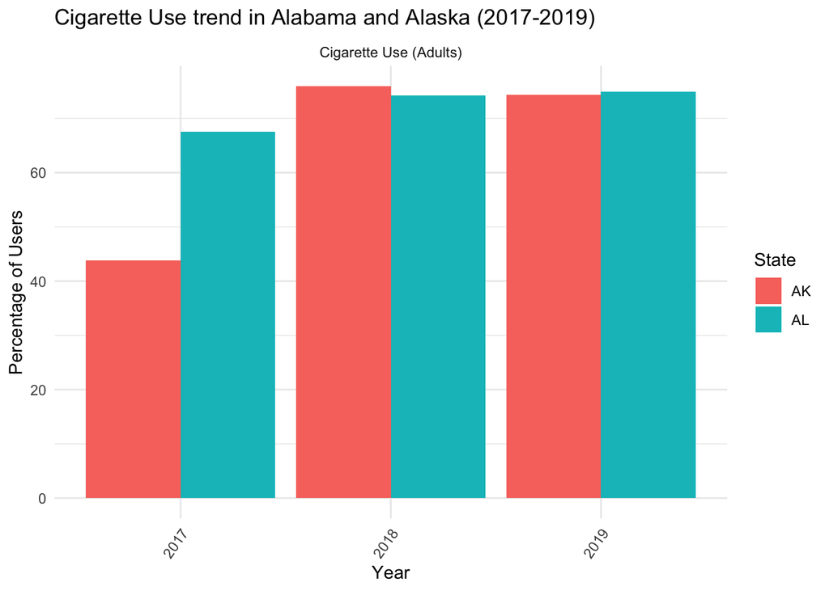

### The Tobacco Use by Education Level in Alabama and Alaska

The analysis of tobacco use by education level further underscores the critical role of education in shaping smoking behaviors. Individuals with less than a high school education exhibited the highest tobacco usage rates in both states, while those with more than a high school education reported significantly lower rates. Notably, the variability in usage was greater among less-educated groups, highlighting the compounded influence of socioeconomic disparities.Public health efforts in Alaska and Alabama should focus on providing targeted tobacco cessation programs for individuals with lower education levels, especially those who did not complete high school. Additionally, the data supports the need for educational campaigns to emphasize the health risks of tobacco use, particularly targeting populations with lower education levels.

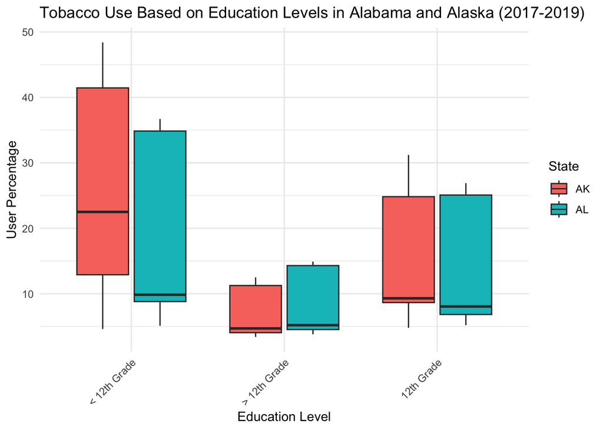

### The tobacco use vary between males and females in Alabama and Alaska from 2018 to 2019.

Tobacco Use by Gender in Alabama and Alaska (2018-2019)

| state | gender | topicdesc | mean_usage | sd_usage |
| --- | --- | --- | --- | --- |
| AK | Female | Cigarette Use (Adults) | 33.61429 | 23.15732 |
| AK | Female | E-Cigarette Use (Adults) | 22.38000 | 32.03197 |
| AK | Female | Smokeless Tobacco Use (Adults) | 26.21250 | 44.18695 |
| AK | Male | Cigarette Use (Adults) | 36.65833 | 18.18648 |
| AK | Male | E-Cigarette Use (Adults) | 34.60000 | 27.72905 |
| AK | Male | Smokeless Tobacco Use (Adults) | 42.06000 | 32.43449 |
| AL | Female | Cigarette Use (Adults) | 34.10000 | 22.91493 |
| AL | Female | Smokeless Tobacco Use (Adults) | 30.62000 | 41.11531 |
| AL | Male | Cigarette Use (Adults) | 36.97500 | 16.79113 |
| AL | Male | Smokeless Tobacco Use (Adults) | 42.35000 | 31.33487 |

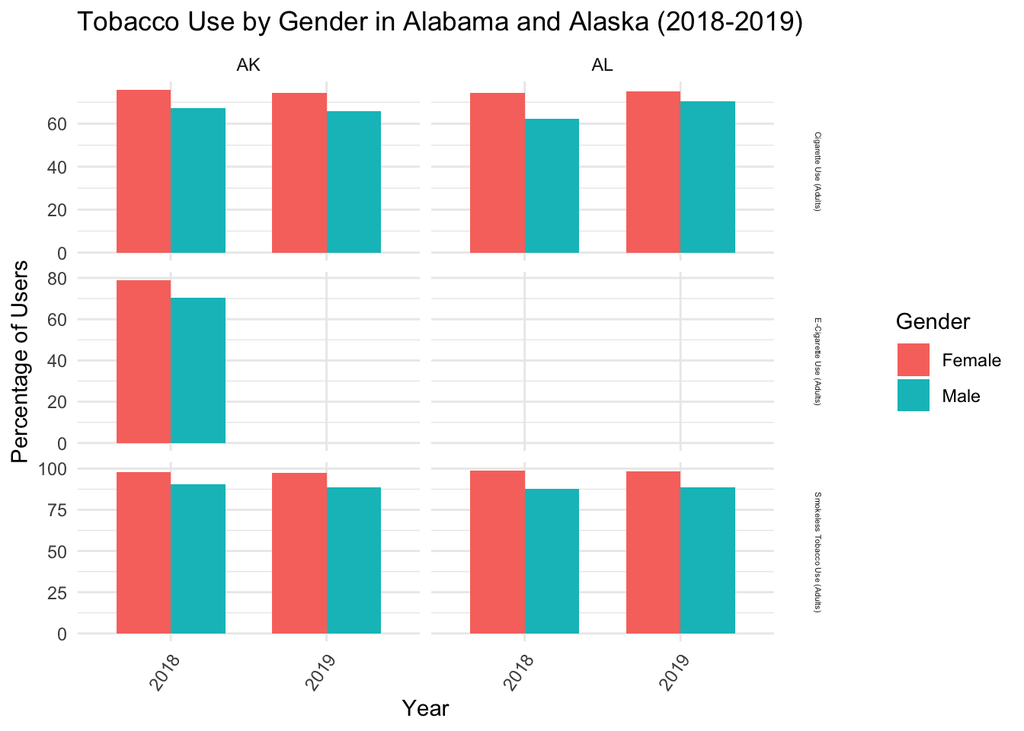

### The mean of different age in different type of tobacco use in Alabama and Alaska

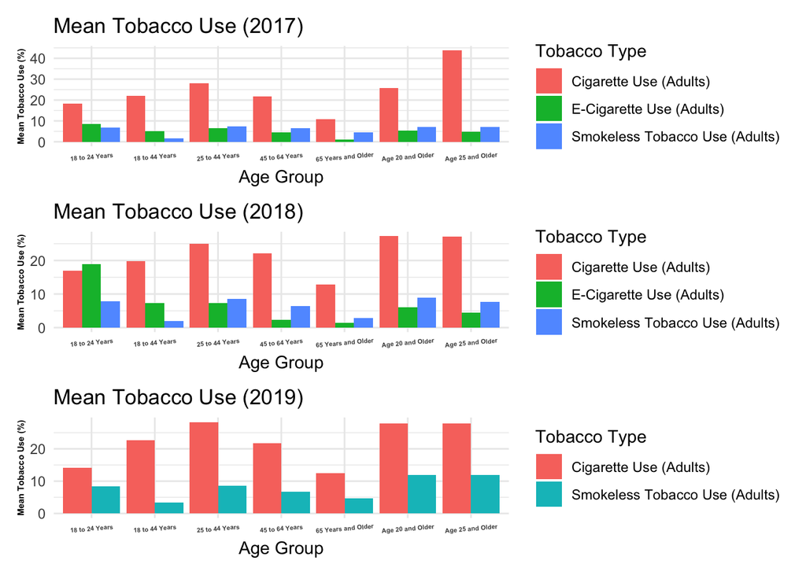